# Project 2: Data Mining, Classification, Prediction

### Dimensionality Reduction with PCA

```r
# fnv_tidy %>% select('Damage Per Shot', 'Rate of Fire',
# 'Weapon Weight', 'Critical Hit Damage', 'Secondary Effect
# Damage', 'Tertiary Effect Damage', 'Skill Required',
# 'Strength Required') %>% na.omit() %>% scale() -> fnv_pca
fnv_tidy_names <- fnv_tidy

fnv_tidy_names <- fnv_tidy_names %>% column_to_rownames("Weapon Name")


fnv_pca <- fnv_tidy_names %>% select_if(is.numeric) %>% select(-"Area of Effect") %>%
    na.omit() %>% scale()

fnv_pca <- fnv_pca %>% princomp(cor = T)


rownames(fnv_pca$scores)
```

```
##   [1] "arc welder"                        "flamer"
##   [3] "cleansing flame"                   "gatling laser"
##   [5] "sprtel-wood 9700"                  "heavy incinerator"
##   [7] "incinerator"                       "plasma caster"
##   [9] "the smitty special"                "tesla cannon"
##  [11] "elijah's jury-rigged tesla cannon" "tesla-beaton prototype"
##  [13] ".357 magnum revolver"              "lucky"
##  [15] ".44 magnum revolver"               "mysterious magnum"
##  [17] ".45 auto pistol"                   "a light shining in darkness"
##  [19] "5.56mm pistol"                     "that gun"
##  [21] "9mm pistol"                        "maria"
##  [23] "10mm pistol"                       "weathered 10mm pistol"
##  [25] "12.7mm pistol"                     "li'l devil"
##  [27] "hunting revolver"                  "ranger sequoia"
##  [29] "police pistol"                     "silenced .22 pistol"
```

[output cut: 36 more lines]

```r
# Finding the PCs of the data
fnv_pca$scores
```

```
##                                        Comp.1      Comp.2       Comp.3
## arc welder                        -0.61589940 -0.94699772 -1.559523920
## flamer                            -1.21564563 -1.03239951 -2.279141931
## cleansing flame                   -3.28228667 -0.26436788 -3.381663333
## gatling laser                     -9.25599386 -3.81794270 -0.710409548
## sprtel-wood 9700                  -6.26568968  0.17834404  0.637077101
##                                         Comp.4       Comp.5       Comp.6
## arc welder                        -0.127097993 -0.440905999 -0.525561434
## flamer                             0.326542576  0.086256930 -0.030949719
## cleansing flame                   -0.476809674 -0.234006759  2.362710234
## gatling laser                     -0.510546873  2.771800015 -0.130333731
## sprtel-wood 9700                  -1.434801630  0.306292060  0.148761251
##                                         Comp.7      Comp.8       Comp.9
## arc welder                        -0.271248203 -0.93355727 -1.107663484
## flamer                             0.519655520 -0.46128962 -1.063400492
## cleansing flame                    2.501679083 -1.55744772 -0.688508721
## gatling laser                      1.107142745  1.29926271  0.470289670
## sprtel-wood 9700                  -0.270063409  0.24622069 -1.439842582
##                                         Comp.10     Comp.11      Comp.12
## arc welder                        -0.2948720313  0.93913381 -1.099111521
## flamer                            -0.0048472695  0.61981127 -0.966382341
## cleansing flame                   -0.8168986655 -0.77091735  0.625535311
## gatling laser                      0.3369247735  0.39694340 -0.552770777
## sprtel-wood 9700                   1.5027256710 -0.62498958  0.289236957
##                                        Comp.13     Comp.14      Comp.15
## arc welder                         0.342387042 -0.49524251 -0.099799153
## flamer                            -0.789808938  0.08725941 -0.406383287
## cleansing flame                   -0.362094500  0.30057914 -0.195116148
## gatling laser                      0.018403158  0.33731305  0.245051718
## sprtel-wood 9700                  -0.352442549 -0.64420880  0.698732289
##                                        Comp.16      Comp.17       Comp.18
## arc welder                        -0.511985261  0.344621280 -0.0694900704
## flamer                            -0.232241469  0.123885320  0.0272967337
## cleansing flame                   -0.675166626 -0.623079561  0.1631539582
## gatling laser                      0.094434953  0.660156734  0.0134827416
## sprtel-wood 9700                  -0.219369380  0.041618113  0.0227165958
##  [ reached getOption("max.print") -- omitted 104 rows ]
```

```r
summary(fnv_pca, loadings = T)
```

```
## Importance of components:
##                           Comp.1    Comp.2     Comp.3     Comp.4     Comp.5
## Standard deviation     2.3493717 1.8104301 1.32127395 1.19881117 1.12498335
## Proportion of Variance 0.3066415 0.1820921 0.09698694 0.07984157 0.07031042
## Cumulative Proportion  0.3066415 0.4887336 0.58572051 0.66556208 0.73587250
##                            Comp.6     Comp.7     Comp.8     Comp.9   Comp.10
## Standard deviation     1.07307674 0.97149664 0.81955937 0.68640070 0.6034073
## Proportion of Variance 0.06397187 0.05243365 0.03731542 0.02617477 0.0202278
## Cumulative Proportion  0.79984437 0.85227802 0.88959344 0.91576822 0.9359960
##                           Comp.11    Comp.12    Comp.13     Comp.14     Comp.15
## Standard deviation     0.55954347 0.48200617 0.42686217 0.403921781 0.343855584
## Proportion of Variance 0.01739383 0.01290722 0.01012285 0.009064045 0.006568703
## Cumulative Proportion  0.95338984 0.96629706 0.97641991 0.985483955 0.992052659
##                           Comp.16     Comp.17      Comp.18
## Standard deviation     0.28018813 0.244935677 0.0674779036
## Proportion of Variance 0.00436141 0.003332971 0.0002529593
## Cumulative Proportion  0.99641407 0.999747041 1.0000000000
##
## Loadings:
##                                           Comp.1 Comp.2 Comp.3 Comp.4 Comp.5
## Damage Per Shot                                   0.417         0.381  0.186
## Damage Per Second                         -0.366         0.191        -0.177
## Rate of Fire                              -0.366 -0.209
## Critical Chance Multiplier                               0.171  0.155  0.525
## Critical Hit Damage                               0.345                0.330
##                                           Comp.6 Comp.7 Comp.8 Comp.9 Comp.10
## Damage Per Shot                            0.133  0.180  0.115  0.103  0.227
## Damage Per Second                                -0.156                0.204
## Rate of Fire                                                           0.311
## Critical Chance Multiplier                 0.501 -0.411 -0.226        -0.316
## Critical Hit Damage                       -0.465         0.114  0.346 -0.247
##                                           Comp.11 Comp.12 Comp.13 Comp.14
## Damage Per Shot                            0.245   0.221   0.262   0.180
## Damage Per Second                         -0.101          -0.602
## Rate of Fire                                      -0.205           0.116
## Critical Chance Multiplier                        -0.185  -0.161
## Critical Hit Damage                       -0.555
##                                           Comp.15 Comp.16 Comp.17 Comp.18
## Damage Per Shot                            0.181   0.338   0.396
## Damage Per Second                         -0.242   0.493   0.176
## Rate of Fire                               0.152  -0.521   0.594
## Critical Chance Multiplier                 0.111
## Critical Hit Damage                                        0.125
##  [ reached getOption("max.print") -- omitted 13 rows ]
```

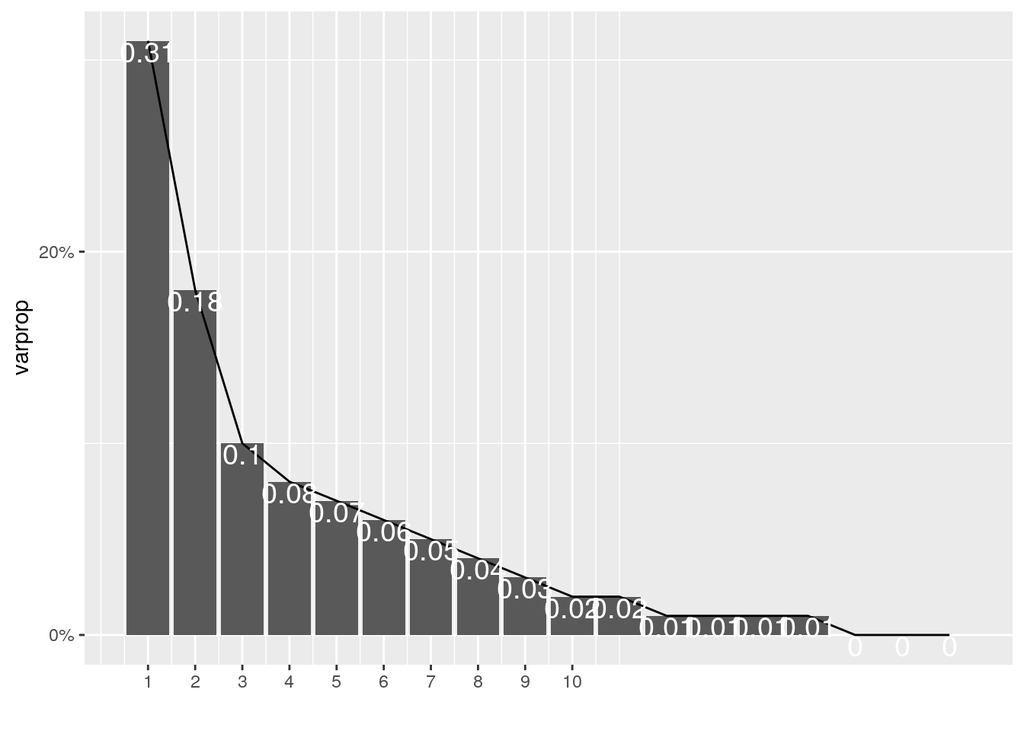

```r
# Visualizing the amount of variation explaining per
# principal component.
fnv_eigen <- fnv_pca$sdev^2
varprop = round(fnv_eigen/sum(fnv_eigen), 2)
ggplot() + geom_bar(aes(y = varprop, x = 1:18), stat = "identity") +
    xlab("") + geom_path(aes(y = varprop, x = 1:18)) + geom_text(aes(x = 1:18,
    y = varprop, label = round(varprop, 2)), vjust = 1, col = "white",
    size = 5) + scale_y_continuous(breaks = seq(0, 0.6, 0.2),
    labels = scales::percent) + scale_x_continuous(breaks = 1:10)
```

```r
fnv_pca_plot <- data.frame(PC1 = fnv_pca$scores[, 1], PC2 = fnv_pca$scores[,
    2], PC3 = fnv_pca$scores[, 3])
scores <- fnv_pca$scores
# Finding 'landmark' weapons
scores[, 1] %>% sort()  #Lowest PC1 score is gatling laser, highest is flare gun. Varmint rifle at 2.635
```

```
##                     gatling laser                      cz57 avenger
##                       -9.25599386                       -8.53363666
##                           minigun                  sprtel-wood 9700
##                       -8.37046365                       -6.26568968
##                             bozar                 light machine gun
##                       -4.84726353                       -4.71981781
##                              fido                the smitty special
##                       -4.09056777                       -3.43854666
##                  silenced .22 smg                k9000 cyberdog gun
##                       -3.39188491                       -3.30628493
##                   cleansing flame      shoulder mounted machine gun
##                       -3.28228667                       -3.23848674
##                      .45 auto smg                        12.7mm smg
##                       -3.01767862                       -2.67180893
##                        sleepytyme                h&h tools nail gun
##                       -2.16038488                       -2.16012914
##                   automatic rifle                   vance's 9mm smg
##                       -2.13474220                       -2.04391778
##                      riot shotgun                   assault carbine
##                       -1.65877863                       -1.60610740
##                     plasma caster                 heavy incinerator
##                       -1.42064341                       -1.33947562
##                            flamer                          10mm smg
##                       -1.21564563                       -1.14494428
##                        li'l devil elijah's jury-rigged tesla cannon
##                       -1.09463734                       -1.07959621
##            tesla-beaton prototype                    medicine stick
##                       -0.95368709                       -0.77157423
##                         laser rcw                      all-american
##                       -0.74881277                       -0.69536716
##                           9mm smg                        arc welder
##                       -0.62436112                       -0.61589940
##                      tesla cannon             mf hyperbreeder alpha
##                       -0.59972872                       -0.51096559
##               survivalist's rifle                  marksman carbine
##                       -0.50784399                       -0.33015599
##                      this machine               anti-materiel rifle
##                       -0.32139507                       -0.28577589
##              tri-beam laser rifle            elijah's advanced laer
##                       -0.14699585                        0.04820784
```

[output cut: 46 more lines]

```
##                       10mm pistol             abilene kid le bb gun
##                        1.79136982                        1.80906402
##                             lucky                           pew pew
##                        1.83955576                        1.85027261
##             weathered 10mm pistol                    single shotgun
##                        1.86346892                        1.87965347
##        sonic emitter - revelation                     police pistol
##                        1.88578724                        1.97091169
##             van graff laser rifle                   cowboy repeater
##                        1.97607089                        1.99678814
##                             maria            van graff plasma rifle
##                        2.06848126                        2.09234979
##                      laser pistol              missing laser pistol
##                        2.20913322                        2.22705928
##  [ reached getOption("max.print") -- omitted 9 entries ]
```

```r
scores[, 2] %>% sort()  #Lowest PC2 score is silenced .22 smg, highest is the medicine stick
```

```
##               silenced .22 smg                  gatling laser
##                    -4.25700562                    -3.81794270
##                         bb gun                        minigun
##                    -3.51125709                    -3.23776827
##           compliance regulator           missing laser pistol
##                    -2.85812531                    -2.79057703
##                   laser pistol            silenced .22 pistol
##                    -2.74947888                    -2.49754946
##          abilene kid le bb gun                     9mm pistol
##                    -2.39609951                    -2.23649639
##                vance's 9mm smg                  service rifle
##                    -2.18965994                    -2.10957616
##          van graff laser rifle             h&h tools nail gun
##                    -2.08484249                    -2.07573180
##                        9mm smg                recharger rifle
##                    -2.03773981                    -1.82066204
##                   cz57 avenger                          maria
##                    -1.81787666                    -1.77068660
##                      laser rcw                      flare gun
##                    -1.68783055                    -1.63991380
##                    laser rifle               recharger pistol
##                    -1.59098145                    -1.56052392
##          weathered 10mm pistol           .357 magnum revolver
##                    -1.41223564                    -1.40064654
##                    10mm pistol                  varmint rifle
##                    -1.34943171                    -1.34840971
##                  plasma pistol                      pulse gun
##                    -1.31727067                    -1.27783096
##                    incinerator                assault carbine
##                    -1.20276514                    -1.18633734
##         sturdy caravan shotgun                       10mm smg
##                    -1.17636863                    -1.13734988
##                          lucky                         flamer
##                    -1.07128651                    -1.03239951
##                      ratslayer                caravan shotgun
##                    -0.96734627                    -0.95507991
##                     arc welder         van graff plasma rifle
##                    -0.94699772                    -0.94663189
##                  police pistol              light machine gun
##                    -0.87664657                    -0.86644956
```

[output cut: 46 more lines]

```
##  sonic emitter - robo-scorpion                     big boomer
##                     1.26164688                     1.29268804
##                multiplas rifle                 ranger sequoia
##                     1.39334289                     1.42763639
##                           laer               hunting revolver
##                     1.57881135                     1.63693634
##         elijah's advanced laer                      holorifle
##                     1.74484205                     1.84571204
##      gobi campaign scout rifle                  alien blaster
##                     2.03710431                     2.08940879
## christine's cos silencer rifle                  plasma caster
##                     2.17515679                     2.37139085
##             the smitty special                    gauss rifle
##                     2.55114311                     2.69562470
##  [ reached getOption("max.print") -- omitted 9 entries ]
```

```r
scores[, 3] %>% sort()  #Lowest PC3 score is the heavy incinerator, highest is the alien blaster.
```

```
##                 heavy incinerator                       incinerator
##                      -5.967418376                      -5.565515642
##                   cleansing flame                         pulse gun
##                      -3.381663333                      -2.295615328
##                            flamer               anti-materiel rifle
##                      -2.279141931                      -2.028227007
##                           minigun                        arc welder
##                      -1.834283070                      -1.559523920
##                      tesla cannon                    single shotgun
##                      -1.498892177                      -1.448049001
##            tesla-beaton prototype                     varmint rifle
##                      -1.423737673                      -1.202295378
## elijah's jury-rigged tesla cannon                     hunting rifle
##                      -1.189523709                      -1.173533655
##                k9000 cyberdog gun                              fido
##                      -1.142075004                      -0.955048107
##                            bb gun                         flare gun
##                      -0.930904589                      -0.866419284
##            van graff plasma rifle                   recharger rifle
##                      -0.853135305                      -0.807758021
##                         ratslayer                       gauss rifle
##                      -0.745857574                      -0.731928154
##                     gatling laser                           ycs/186
##                      -0.710409548                      -0.702072500
##                   automatic rifle                      plasma rifle
##                      -0.674580571                      -0.642385628
##             abilene kid le bb gun    christine's cos silencer rifle
##                      -0.633944860                      -0.593356942
##                     plasma caster      shoulder mounted machine gun
##                      -0.576968937                      -0.526998712
##                   cowboy repeater                      sniper rifle
##                      -0.485736213                      -0.437900645
##                     plasma pistol        sonic emitter - revelation
##                      -0.420672912                      -0.368467810
##                      battle rifle                   multiplas rifle
##                      -0.293670330                      -0.292196483
##                    ranger sequoia                the smitty special
##                      -0.275300979                      -0.244584093
##                         brush gun                  hunting revolver
##                      -0.212733423                      -0.211300925
```

[output cut: 46 more lines]

```
##            sturdy caravan shotgun                             maria
##                       0.964833494                       0.983004339
##                          10mm smg                     12.7mm pistol
##                       0.990946917                       1.041096005
##                  marksman carbine                   caravan shotgun
##                       1.049241746                       1.103297321
##                    medicine stick                   plasma defender
##                       1.147031573                       1.153042620
##                           9mm smg                   .45 auto pistol
##                       1.168888940                       1.229190495
##                      all-american                             bozar
##                       1.305936804                       1.358235005
##                h&h tools nail gun                      .45 auto smg
##                       1.359898000                       1.376852851
##  [ reached getOption("max.print") -- omitted 9 entries ]
```

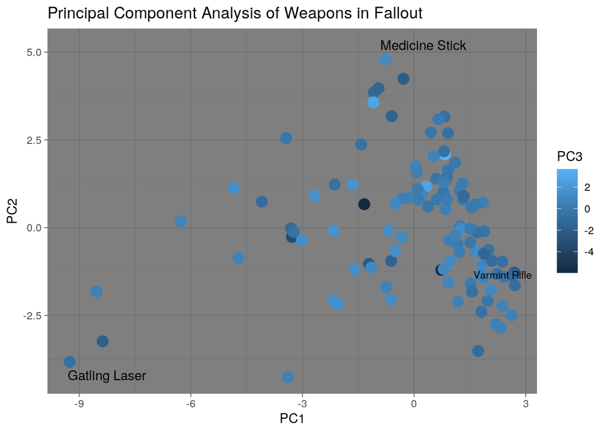

```r
# Graphing the first three (technically) PCs
fnv_pca_plot %>% ggplot(aes(x = PC1, y = PC2)) + geom_point(size = 4,
    aes(color = PC3)) + labs(title = "Principal Component Analysis of Weapons in Fallout") +
    theme_dark() + annotate("text", x = -8.25, y = -4.2, label = "Gatling Laser") +
    annotate("text", x = 0.25, y = 5.2, label = "Medicine Stick") +
    annotate("text", x = scores[, 1][rownames(scores) == "varmint rifle"] -
        0.25, y = scores[, 2][rownames(scores) == "varmint rifle"],
        label = "Varmint Rifle", size = 3)
```

I performed principal component analysis across all numeric variables in the data (excluding Area of Effect) for weapons that have values for such variables (essentially all of the ballistic and energy weapons). The first 6 components describe an acceptable amount of variation (0.80) across all 18 variables. PC1 tends to negatively correlate with variables that more effective weapons score highly in: as PC1 increases, skill and strength required to wield the weapon, the weapon weight and value, durability, magazine capacity, weapon spread, and damage per second all decrease, which means that we can expect to find more effective (and heavier) weapons as PC1 decreases. PC2 seems to indicate that the weapon is a semi-automatic rifle the higher the PC2 score is; such weapons tend to require more skill and strength, but also deal more damage per shot, have a higher monetary value, a slower rate of fire, and higher critical damage. PC3 seems to indicate the weapon’s similarity to a pistol or energy pistol; weapons that score highly in PC3 are lighter, more valuable, have higher rates of fire and damage per second,and require less skill to use.